# Trawl Data Analysis

Marissa Leatherman

12/5/2019

# Distributions of *Gadus* and *Pagurus*

## Comparing Arctic cod *Gadus* and known prey the hermit crab genus *Pagurus*.

### How do the distributions of known predator and prey compare?

### How do the distributions change with location, depth, and water temperature?

#### In this document:

1. Data from NOAA Alaskan Trawls will be merged and organized to maximize data from all parts of the Bering Sea.
2. Data will be filtered and chosen, then analyzed for graphical use
3. Visualizations will be made that display the distribution of the two species by location, water temperature and depth.

## Imported library

### A lot of packages were needed to complete this project:

1. tidyverse, using ggplot2, tidyr, and dplyr to organize data
2. rnaturalearth, rnaturalearthdata for world map data
3. ggmap, maps and mapdata for map data as well
4. rgeos and sf for error-fixing/ map holes

## Data merged to maximize area of map

### Trawls from The Aleutian Islands, North and East Bering Sea, the Bering Sea slope and the Gulf of Alaska all merged

##### Trawls taken at different years for different number of years, future work could be more accurate by making sure years match, could make time plots

## Select data using tidyr and dplyr

- Separated scienticic name column into Genus and species columns
- Separated date-time column into date and time columns
- Select data relevent for current and furture anaylysis

## Filtered out *Pagurus* and *Gadus* genuses

### Two most common and known predator-prey relationship

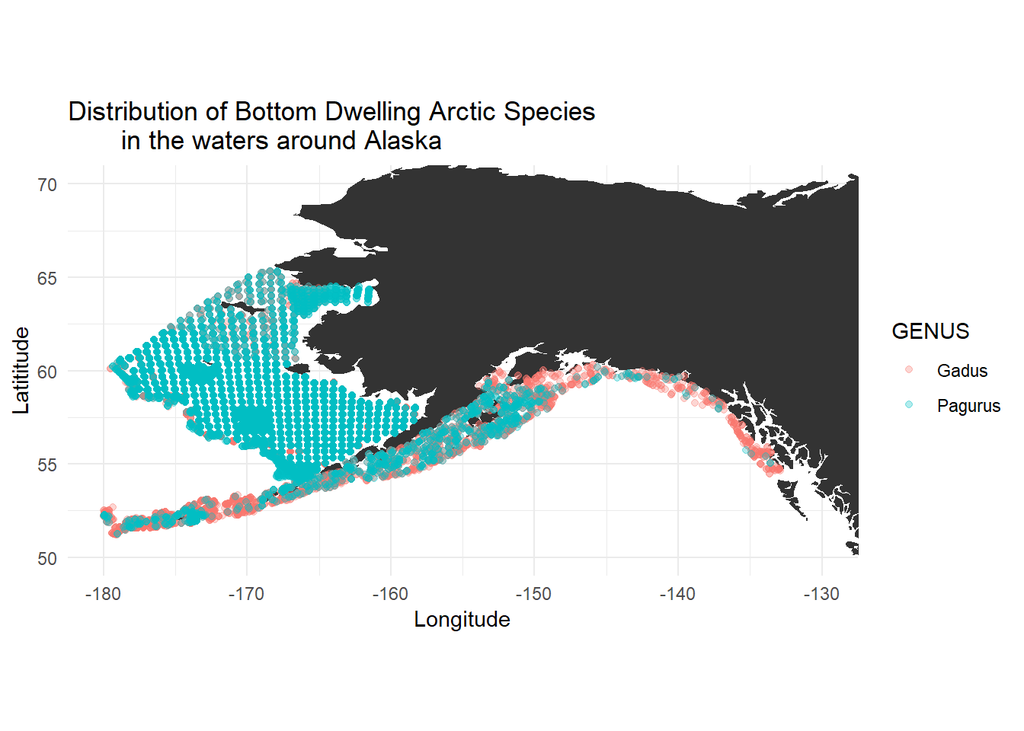

```r
sites <- st_as_sf(trawl, coords = c("LONGITUDE", "LATITUDE"), crs = 4326, agr = "constant")
world <- map_data("world")
plt1 <-
  ggplot() +
  theme_minimal()+
  labs(x='Longitude',y='Latititude')+
  labs(title='Distribution of Bottom Dwelling Arctic Species
       in the waters around Alaska')+
  geom_polygon(data = world, aes(x = long, y = lat, group=group)) +
  coord_fixed(xlim = c(-180.0, -130.0), ylim = c(50., 70.), ratio = 1.3) +
  geom_point(data=trawl, aes(x= LONGITUDE, y = LATITUDE, fill=GENUS, color=GENUS), alpha = 0.3)
plt1
```

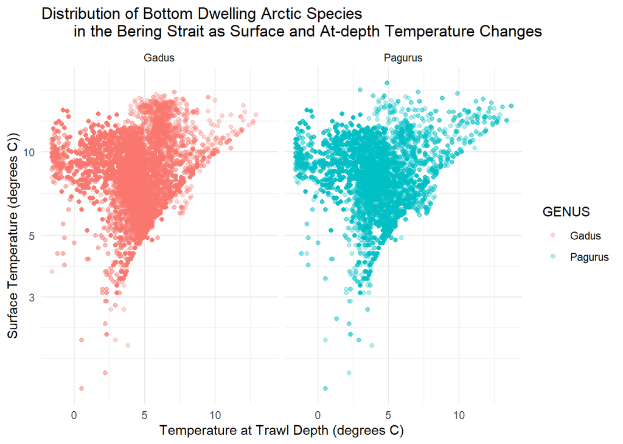

```r
ggplot() +
  geom_point(data=trawl, mapping = aes(x = BOT_TEMP,y=SURF_TEMP, color=GENUS), alpha = 0.3)+
  theme_minimal()+
  scale_y_log10()+
  scale_x_continuous()+
  labs(x='Temperature at Trawl Depth (degrees C)',y='Surface Temperature (degrees C))')+
  labs(title='Distribution of Bottom Dwelling Arctic Species
       in the Bering Strait as Surface and At-depth Temperature Changes')+
  facet_wrap(~GENUS)
```

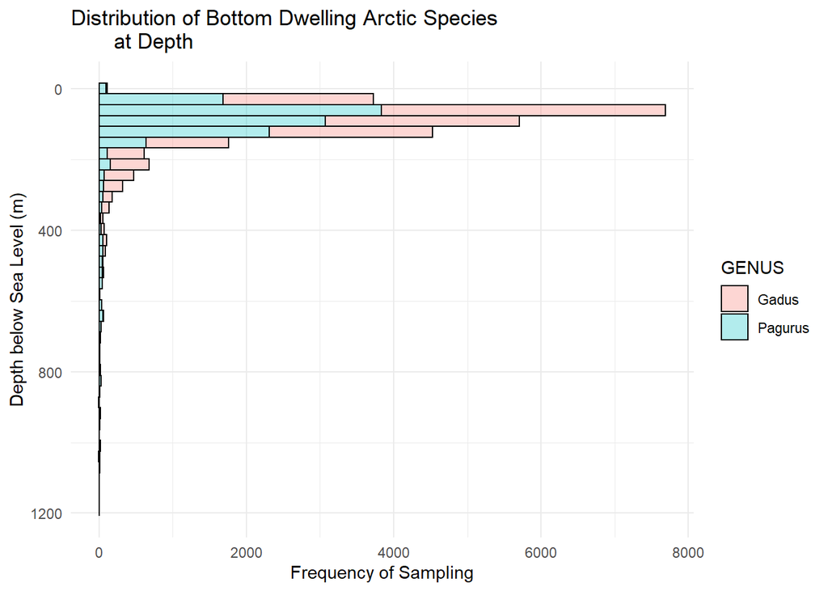

```r
ggplot() +
  geom_histogram(data=trawl, mapping = aes(x = BOT_DEPTH, fill=GENUS), alpha = 0.3, bins=40, color='black')+
  scale_y_continuous(position = 'top')+
  theme_minimal()+
  coord_flip()+
  scale_x_reverse()+
  labs(y='Frequency of Sampling',x='Depth below Sea Level (m)')+
  labs(title='Distribution of Bottom Dwelling Arctic Species
       at Depth')
```